# Unsupervised Learning

Melinda Higgins

April 10, 2018

## Working with the IRIS Dataset

In R, one of the builtin datasets is `iris`, which is a famous (Fisher’s or Anderson’s) data set (published in 1936) that gives the measurements in centimeters of the variables sepal length and width and petal length and width, respectively, for 50 flowers from each of 3 species of iris. The species are Iris setosa, versicolor, and virginica.

| Iris Setosa | Iris Versicolor | Iris Virginica |
| --- | --- | --- |

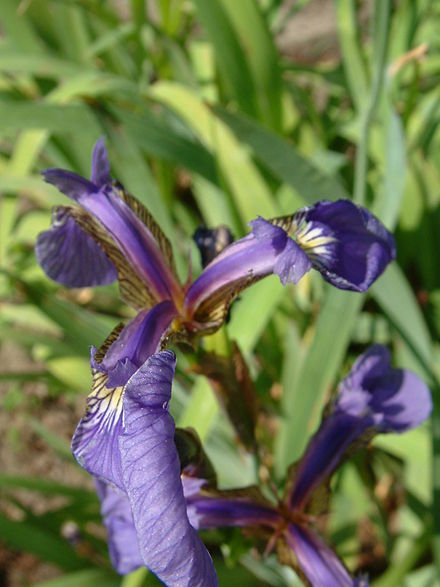

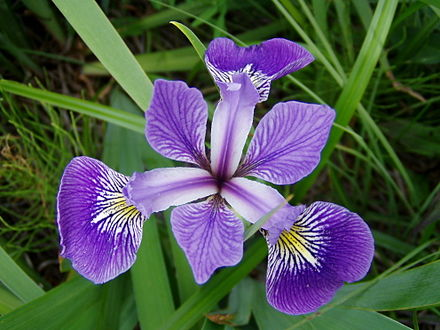

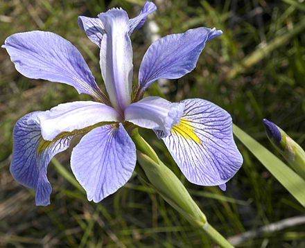

### Sepal Length and Width; Petal Length and Width

Here is a diagram of the measurements - image is of iris versicolor

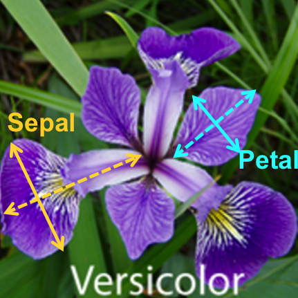

iris measurements

### Load the IRIS dataset

The `head()` command will show us the first 6 rows of the dataset so you get an idea of what’s inside the dataset.

```r
data(iris)
head(iris)
```

| Sepal.Length | Sepal.Width | Petal.Length | Petal.Width | Species |
| --- | --- | --- | --- | --- |
| 5.1 | 3.5 | 1.4 | 0.2 | setosa |
| 4.9 | 3.0 | 1.4 | 0.2 | setosa |
| 4.7 | 3.2 | 1.3 | 0.2 | setosa |
| 4.6 | 3.1 | 1.5 | 0.2 | setosa |
| 5.0 | 3.6 | 1.4 | 0.2 | setosa |
| 5.4 | 3.9 | 1.7 | 0.4 | setosa |